# LM: Assumptions and Outliers

2018-05-15

## The Linear Model: LM

- 2.0 Introduction
- 2.1 Point estimates
- 2.2 Uncertainty in point estimates
- 2.3 Tests
- 2.4 Assumptions and Outliers
- 2.5 Let's practice more

## You will learn in this session

- the six main assumptions behind LM
- how to check if these assumptions are met (by means of tests and using your eyes)
- how to do the Box-Cox transformation
- that you can manipulate the design matrix to solve problems
- how to study carefully outliers
- that you will have to learn GLM and (G)LMM to solve some usual problems

## Introduction

## The main assumptions

### Model structure

- linearity
- lack of perfect multicollinearity (design matrix of full rank)
- predictor variables have fixed values

### Errors

- independence (no serial autocorrelation)
- constant variance (homoscedasticity)
- normality

## Assumptions about the model structure

## Linearity

## Linearity in brief

### Assumption

The mean of the response variable must be a linear combination of the parameters and the predictor variables, with no systematic dependence on any omitted terms.

### Causes and consequences of violation

Departure from linearity can originate from a multitude of reasons and can create all kinds of problems.

### Solution

- transform one or several predictors (e.g. polynomials)
- transform the response (e.g. log and power transformation)

### Alternative

- non-linear models

## Quiz

### Can you express the following models as LM?

- \(y_i = \alpha + \epsilon_i\)
- \(y_i = x_i^\beta + \epsilon_i\)
- \(y_i = \alpha + \beta_1 x_i + \beta_2 x_i^2 + \beta_3 x_i^3 + \epsilon_i\)
- \(y_i = \frac{\beta x_i}{\alpha + x_i} + \epsilon_i\) (Michaelis-Menten : V = Vmax[S]/(Km+[S]))

## Lineweaver Burk method for Michaelis-Menten

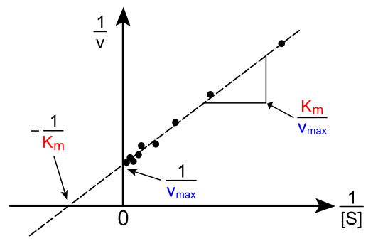

But using this method is not advised as results can be unreliable…

## A simple example of non-linearity

```r
set.seed(1L)
Alien0 <- data.frame(humans_eaten = sample(1:100))
Alien0$size <- 10 + 50 * Alien0$humans_eaten - 0.02 * (Alien0$humans_eaten^2) + rnorm(100, sd = 5)
mod0a <- lm(size ~ humans_eaten, data = Alien0)
coef(mod0a)
```

```
##  (Intercept) humans_eaten
##     45.17690     47.96169
```

## A simple example of non-linearity

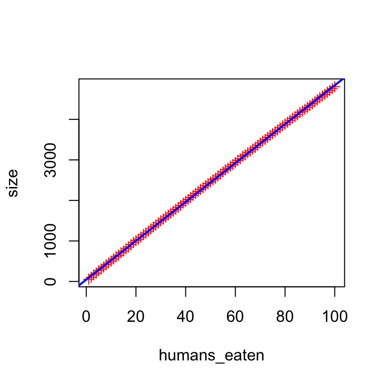

```r
plot(size ~ humans_eaten, data = Alien0, pch = 3, col = "red")
abline(mod0a, col = "blue", lwd = 2)
```

## A simple example of non-linearity

Solution for continuous design matrix column vectors: plot the residuals against them!

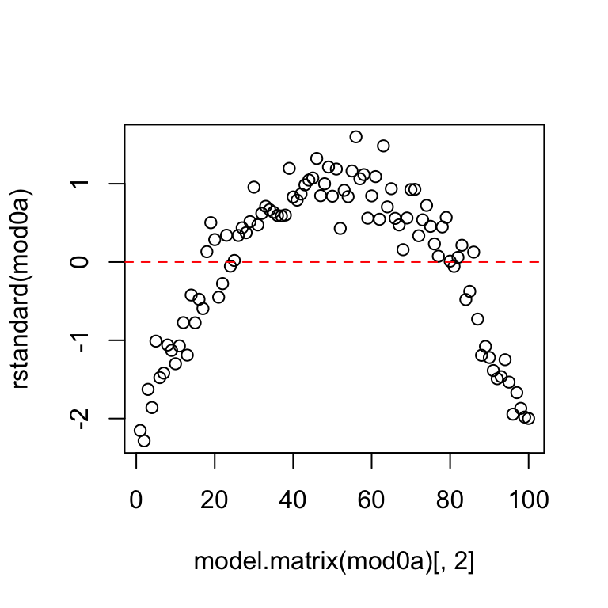

```r
plot(rstandard(mod0a) ~ model.matrix(mod0a)[,2])  ## using standardized residuals
abline(h = 0, col = "red", lty = 2)
```

## A simple example of non-linearity

```r
mod0b <- lm(size ~ poly(humans_eaten, 2, raw = TRUE), data = Alien0)
summary(mod0b)$coef
```

```
##                                      Estimate   Std. Error    t value      Pr(>|t|)
## (Intercept)                         8.3783284 1.4055538564   5.960873  4.054129e-08
## poly(humans_eaten, 2, raw = TRUE)1 50.1263091 0.0642376320 780.326230 5.149331e-186
## poly(humans_eaten, 2, raw = TRUE)2 -0.0214319 0.0006162071 -34.780354  1.406585e-56
```

## Another example of non-linearity

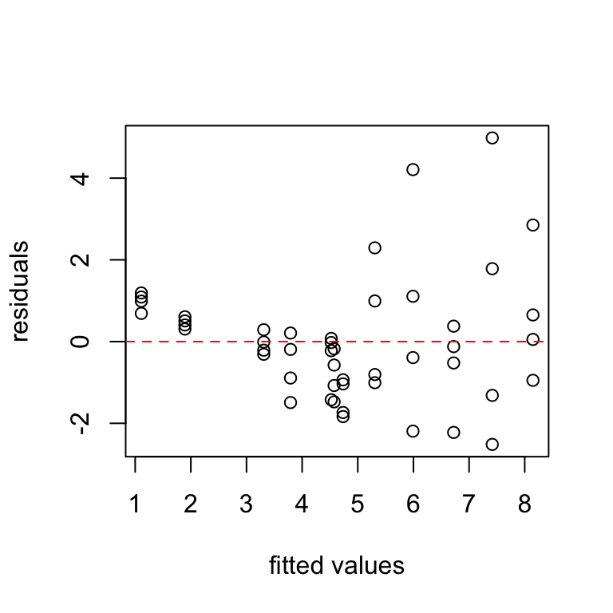

```r
data(poison, package = "fastR")  ##  ?fastR::poison for description
poison$treat <- factor(poison$Treatment)
poison$poison <- factor(poison$Poison)
mod_poison <- lm(Time ~ poison + treat, data = poison)
plot(residuals(mod_poison) ~ fitted(mod_poison), xlab = "fitted values", ylab = "residuals")
abline(h = 0, col = "red", lty = 2)
```

## The Box-Cox transformation (Box & Cox 1964)

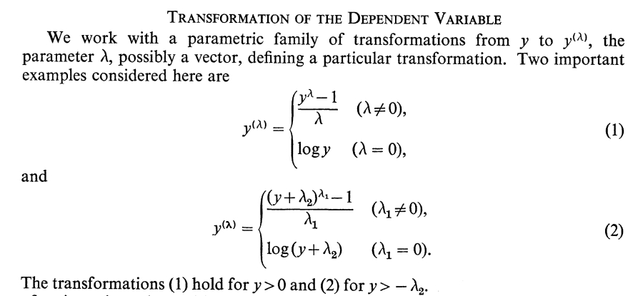

## The Box-Cox transformation (Box & Cox 1964)

### It encompasses several classic transformations:

- log transformation (\(\lambda = 0\))
- inverse transformation (\(\lambda = -1\))
- square root transformation (\(\lambda = 1/2\))
- square transformation (\(\lambda = 2\))

(but it changes intercept and rescale the \(\beta\))

## The Box-Cox transformation (Box & Cox 1964)

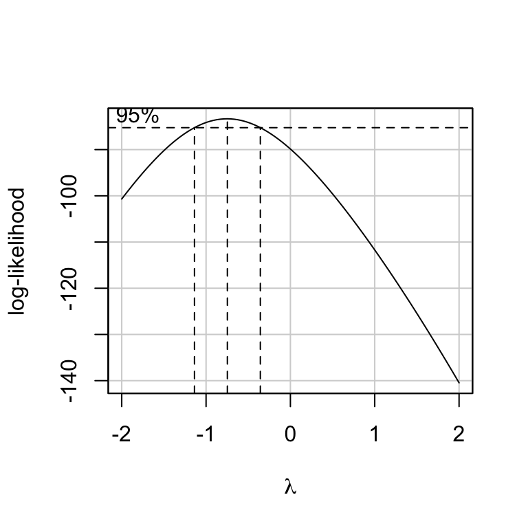

```r
library(car)
boxCox(mod_poison)  ## makes logLik profile!
```

## The Box-Cox transformation (Box & Cox 1964)

```r
summary(bc <- powerTransform(mod_poison))
```

```
## bcPower Transformation to Normality
##    Est Power Rounded Pwr Wald Lwr Bnd Wald Upr Bnd
## Y1   -0.7502          -1      -1.1369      -0.3634
##
## Likelihood ratio test that transformation parameter is equal to 0
##  (log transformation)
##                            LRT df       pval
## LR test, lambda = (0) 13.07606  1 0.00029909
##
## Likelihood ratio test that no transformation is needed
##                            LRT df       pval
## LR test, lambda = (1) 56.76089  1 4.9183e-14
```

```r
testTransform(bc, lambda = -1)
```

```
##                            LRT df    pval
## LR test, lambda = (-1) 1.60508  1 0.20518
```

We will consider -1 instead of `-0.75` as it is close enough and easier to interpret!

## Poison example linearised

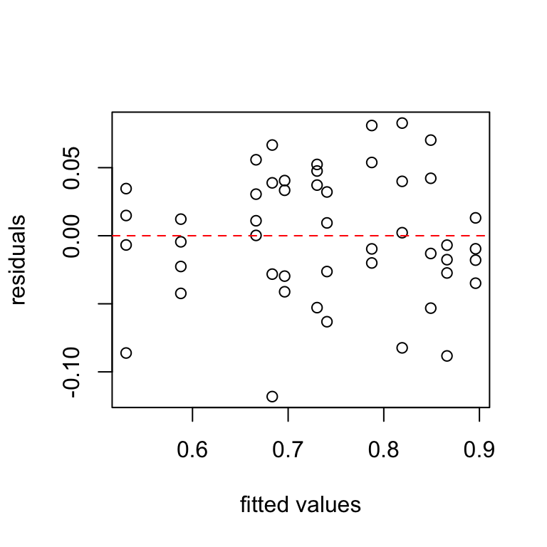

```r
mod_poison2 <- update(mod_poison, bcPower(Time, lambda = -1) ~ .)
plot(residuals(mod_poison2) ~ fitted(mod_poison2), xlab = "fitted values", ylab = "residuals")
abline(h = 0, col = "red", lty = 2)
```

## Poison example linearised

### Predictions

```r
data.for.pred <- expand.grid(treat = levels(poison$treat), poison = levels(poison$poison))
(pred <- cbind(data.for.pred, predict(mod_poison2, newdata = data.for.pred, interval = "confidence")))
```

```
##    treat poison       fit       lwr       upr
## 1      1      1 0.7302343 0.6950488 0.7654199
## 2      2      1 0.8959746 0.8607891 0.9311601
## 3      3      1 0.7874479 0.7522624 0.8226334
## 4      4      1 0.8660682 0.8308827 0.9012537
## 5      1      2 0.6833702 0.6481847 0.7185557
## 6      2      2 0.8491105 0.8139249 0.8842960
## 7      3      2 0.7405838 0.7053982 0.7757693
## 8      4      2 0.8192040 0.7840185 0.8543896
## 9      1      3 0.5305918 0.4954063 0.5657774
## 10     2      3 0.6963321 0.6611466 0.7315176
## 11     3      3 0.5878054 0.5526199 0.6229909
## 12     4      3 0.6664257 0.6312402 0.7016112
```

There are in the Box-Cox scales. In this case, it represents the survival rate, but you can always get back to the original scale:

```r
lambda <- -1; (pred$fit * lambda + 1)^(1/lambda)
```

```
##  [1] 3.706921 9.613035 4.704729 7.466485 3.158263 6.627364 3.854809 5.531097 2.130342 3.293071 2.426039 2.997833
```

## Comparison of tests

```r
summary(mod_poison) ## the original model
```

```
##
## Call:
## lm(formula = Time ~ poison + treat, data = poison)
##
## Residuals:
##     Min      1Q  Median      3Q     Max
## -2.5167 -0.9625 -0.1490  0.6177  4.9833
##
## Coefficients:
##             Estimate Std. Error t value Pr(>|t|)
## (Intercept)   4.5229     0.5592   8.088 4.22e-10 ***
## poison2      -0.7313     0.5592  -1.308  0.19813
## poison3      -3.4125     0.5592  -6.102 2.83e-07 ***
## treat2        3.6250     0.6458   5.614 1.43e-06 ***
## treat3        0.7833     0.6458   1.213  0.23189
## treat4        2.2000     0.6458   3.407  0.00146 **
## ---
## Signif. codes:  0 '***' 0.001 '**' 0.01 '*' 0.05 '.' 0.1 ' ' 1
##
## Residual standard error: 1.582 on 42 degrees of freedom
## Multiple R-squared:  0.6503, Adjusted R-squared:  0.6087
## F-statistic: 15.62 on 5 and 42 DF,  p-value: 1.123e-08
```

## Comparison of tests

```r
summary(mod_poison2) ## the boxcoxed model
```

```
##
## Call:
## lm(formula = bcPower(Time, lambda = -1) ~ poison + treat, data = poison)
##
## Residuals:
##       Min        1Q    Median        3Q       Max
## -0.118153 -0.027568 -0.002116  0.037619  0.082757
##
## Coefficients:
##             Estimate Std. Error t value Pr(>|t|)
## (Intercept)  0.73023    0.01744  41.883  < 2e-16 ***
## poison2     -0.04686    0.01744  -2.688  0.01026 *
## poison3     -0.19964    0.01744 -11.451 1.69e-14 ***
## treat2       0.16574    0.02013   8.233 2.66e-10 ***
## treat3       0.05721    0.02013   2.842  0.00689 **
## treat4       0.13583    0.02013   6.747 3.35e-08 ***
## ---
## Signif. codes:  0 '***' 0.001 '**' 0.01 '*' 0.05 '.' 0.1 ' ' 1
##
## Residual standard error: 0.04931 on 42 degrees of freedom
## Multiple R-squared:  0.8441, Adjusted R-squared:  0.8255
## F-statistic: 45.47 on 5 and 42 DF,  p-value: 6.974e-16
```

## Lack of perfect multicollinearity

## Lack of perfect multicollinearity in brief

### Assumption

The design matrix must have full rank. That means that the number of parameters to be estimated must be equal to the rank of the design matrix.

### Causes and consequences of violation

Caused by having less data than parameters or when there is linear dependence between the column vectors of the design matrix. In such case, some parameters cannot be computed.

### Solution

- change design matrix (change parameterization or drop redundant effects)
- change the experimental design
- collect more data

### Alternative

- none

## Degenerated design matrix: `n < p`

```r
set.seed(1L)
N <- 3
Alien <- data.frame(humans_eaten = 1:N,
                    flowers_eaten = round(runif(N, min = 1, max = 15)),
                    cactus_eaten =  round(runif(N, min = 1, max = 10)))

Alien$size <- rnorm(n = nrow(Alien),
  mean = 50 + 0.2 * Alien$humans_eaten + 0.9 * Alien$flowers_eaten + 0.1 * Alien$cactus_eaten,
  sd = sqrt(25))

mod_alien1a <- lm(size ~  cactus_eaten + humans_eaten + flowers_eaten, data = Alien)
coef(mod_alien1a)
```

```
##   (Intercept)  cactus_eaten  humans_eaten flowers_eaten
##    64.9315387     0.2982487    -4.0393730            NA
```

```r
mod_alien1b <- lm(size ~  humans_eaten + flowers_eaten + cactus_eaten, data = Alien)
coef(mod_alien1b)
```

```
##   (Intercept)  humans_eaten flowers_eaten  cactus_eaten
##     62.247300     -7.618357      1.789492            NA
```

## Degenerated design matrix: trivial redundancy

```r
set.seed(1L)
Alien2 <- simulate_Aliens()
Alien2$half_humans_eaten <-  0.5 * Alien2$humans_eaten
mod_alien2 <- lm(size ~ humans_eaten + half_humans_eaten, data = Alien2)
coef(mod_alien2)
```

```
##       (Intercept)      humans_eaten half_humans_eaten
##        57.1360531         0.5668555                NA
```

```r
det(crossprod(model.matrix(mod_alien2)))  ## when det(XTX) <= 0, XTX has no inverse!
```

```
## [1] 0
```

```r
mod_alien2$rank  == ncol(model.matrix(mod_alien2))
```

```
## [1] FALSE
```

## Degenerated design matrix: miscellaneous

```r
set.seed(1L)
Alien3 <- data.frame(humans_eaten = 1:12,
                     flowers_eaten = round(runif(12, min = 1, max = 15)),
                     cactus_eaten = 0)
Alien3$food_units <- 1.2*Alien3$humans_eaten + 0.6*Alien3$flowers_eaten
Alien3$size <- rnorm(n = 12, mean = 50 + 1*Alien3$food_units, sd = sqrt(25))
mod_alien3 <- lm(size ~ food_units + humans_eaten + flowers_eaten + cactus_eaten, data = Alien3)
coef(mod_alien3)
```

```
##   (Intercept)    food_units  humans_eaten flowers_eaten  cactus_eaten
##    57.0699098     0.2101724     0.6020063            NA            NA
```

```r
caret::findLinearCombos(model.matrix(mod_alien3))  ## Tip: help to see what creates the issue
```

```
## $linearCombos
## $linearCombos[[1]]
## [1] 4 2 3
##
## $linearCombos[[2]]
## [1] 5
##
##
## $remove
## [1] 4 5
```

## Challenge: analysing the Fungi dataset

```r
head(Fungi)
```

```
##   colony species T36 T38 PT36 PT38 alive   growth
## 1      B     M_A   1   0    1    0  TRUE 1.875000
## 2      C     M_A   1   0    1    0  TRUE 2.892857
## 3      A     M_A   1   0    1    0  TRUE 3.107143
## 4      A     M_A   1   0    1    0  TRUE 3.285714
## 5      C     M_A   1   0    1    0  TRUE 3.812500
## 6      B     M_A   1   0    1    0  TRUE 3.937500
```

### Goal:

quantifying the average growth rate of alive fungi for each species, in each experimental condition, using a single linear model.

## Non-perfect multicollinearity

### Sometimes assumptions are met, but problems can still occur

```r
summary(mod_US  <- lm(Rape ~ Assault + Murder, data = USArrests))$coef
```

```
##               Estimate Std. Error   t value    Pr(>|t|)
## (Intercept) 8.35010661 2.32911542 3.5850978 0.000798757
## Assault     0.06715833 0.02043898 3.2857966 0.001927212
## Murder      0.18155319 0.39107635 0.4642398 0.644619230
```

```r
summary(mod_US2 <- lm(Rape ~ Murder, data = USArrests))$coef
```

```
##              Estimate Std. Error  t value     Pr(>|t|)
## (Intercept) 11.793269  2.2824873 5.166850 4.556492e-06
## Murder       1.211958  0.2564042 4.726749 2.030826e-05
```

It is a problem to infer causal inference, not so much for predictions!

## Non-perfect multicollinearity: why?

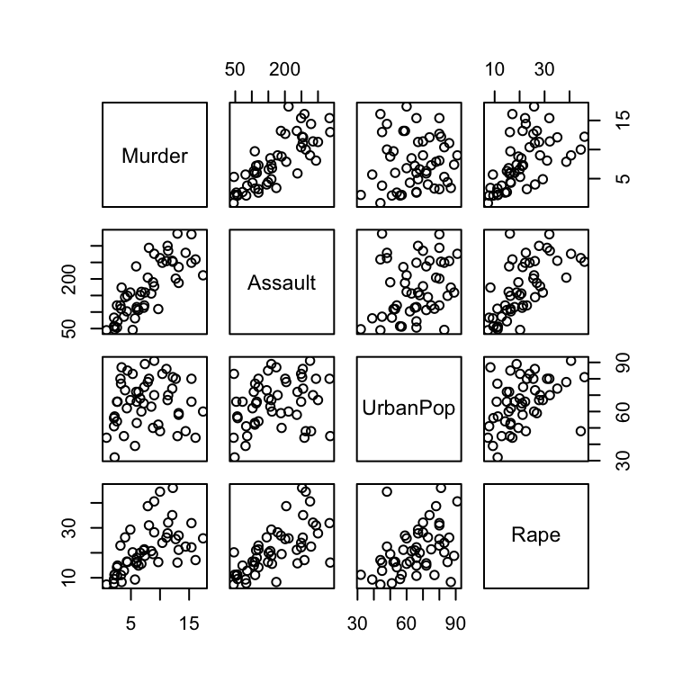

```r
pairs(USArrests)
```

## Non-perfect multicollinearity: why?

```r
crossprod(model.matrix(mod_US))  ## remember: high values show collinearity
```

```
##             (Intercept) Assault  Murder
## (Intercept)        50.0    8538   389.4
## Assault          8538.0 1798262 80756.0
## Murder            389.4   80756  3962.2
```

```r
cor(USArrests$Assault, USArrests$Murder)
```

```
## [1] 0.8018733
```

## Non-perfect multicollinearity: why?

```r
cor(model.matrix(mod_US))  ## direct measure of correlation in the design matrix
```

```
##             (Intercept)   Assault    Murder
## (Intercept)           1        NA        NA
## Assault              NA 1.0000000 0.8018733
## Murder               NA 0.8018733 1.0000000
```

```r
cov2cor(vcov(mod_US))  ## direct measure of correlation between parameter estimates
```

```
##             (Intercept)    Assault     Murder
## (Intercept)   1.0000000 -0.4499102 -0.1060644
## Assault      -0.4499102  1.0000000 -0.8018733
## Murder       -0.1060644 -0.8018733  1.0000000
```

In more complex models, the numbers do not necessarily match, so it is good practice to check both matrices.

## Non-perfect multicollinearity: why?

### Often diagnosed using the Variance Inflation Factor

```r
vif(mod_US)
```

```
##  Assault   Murder
## 2.801127 2.801127
```

```r
R2 <- summary(lm(Assault ~ Murder, data = USArrests))$r.squared  ## works too if more variables
1/(1 - R2)
```

```
## [1] 2.801127
```

Note: the model here considers the relationship between the predictors (the response variable of `mod_US` was `rape`).

The VIF tells you by how much the variance in the uncertainty in parameter estimates increases due to multicollinearity.

## Non-perfect multicollinearity: solution?

- drop one variable
- merge them

```r
pca <- prcomp(~ Assault + Murder, data = USArrests, scale. = TRUE)
USArrests$PC1 <- pca$x[, 1]
summary(mod_US3 <- lm(Rape ~ PC1, data = USArrests))
```

```
##
## Call:
## lm(formula = Rape ~ PC1, data = USArrests)
##
## Residuals:
##     Min      1Q  Median      3Q     Max
## -15.325  -3.983  -1.219   2.457  18.419
##
## Coefficients:
##             Estimate Std. Error t value Pr(>|t|)
## (Intercept)  21.2320     1.0201  20.813  < 2e-16 ***
## PC1          -4.5167     0.7677  -5.884 3.77e-07 ***
## ---
## Signif. codes:  0 '***' 0.001 '**' 0.01 '*' 0.05 '.' 0.1 ' ' 1
##
## Residual standard error: 7.213 on 48 degrees of freedom
## Multiple R-squared:  0.419,  Adjusted R-squared:  0.4069
## F-statistic: 34.62 on 1 and 48 DF,  p-value: 3.773e-07
```

## Predictor variables have fixed values

## Predictor variables have fixed values (in brief)

### Causes and consequences of violation

The presence of measurement errors is the main cause of violation. Violation can trigger both estimates and tests to be biased.

### Solution

- often ignored in practice
- better measurements

### Alternative

- multipurpose numerical approaches
- errors-in-variables models
- reduced major axis regression

## Example

```r
set.seed(1L)
Alien4 <- simulate_Aliens(100)
summary(lm(size ~ humans_eaten, data = Alien4))$coef
```

```
##               Estimate Std. Error  t value     Pr(>|t|)
## (Intercept)  50.836903 0.94583127 53.74838 1.572750e-74
## humans_eaten  1.481687 0.01626038 91.12256 1.530244e-96
```

```r
Alien4$humans_eaten_err <- Alien4$humans_eaten + rnorm(nrow(Alien4), sd = 10)
summary(lm(size ~ humans_eaten_err, data = Alien4))$coef
```

```
##                  Estimate Std. Error  t value     Pr(>|t|)
## (Intercept)      59.98334 2.84017324 21.11960 2.962482e-38
## humans_eaten_err  1.29473 0.04768244 27.15317 2.146216e-47
```

## Accounting for errors-in-variables using `sem`

### Seems to work here… (despite strange value for phi)

```r
library(sem)
eqns <- specifyEquations(text = "
                        size = alpha*Intercept + slope*humans_eaten
                        humans_eaten = 1*humans_eaten_err
                        V(size) = sigma
                        V(humans_eaten) = 1
                        V(humans_eaten_err) = phi
                        ")
fitted.mod <- sem(eqns, data = Alien4, raw = TRUE, fixed.x = "Intercept")
summary(fitted.mod, analytic.se = FALSE)$coef  ## use analytic.se = FALSE (uses z as consider variance known)
```

```
##          Estimate    Std Error   z value     Pr(>|z|)
## alpha   50.836895   0.93632546 54.294043 0.000000e+00                    size <--- Intercept
## slope    1.481687   0.01609694 92.047754 0.000000e+00                 size <--- humans_eaten
## sigma   21.590445   3.05408240  7.069372 1.556363e-12                         size <--> size
## phi   3547.910575 504.80532928  7.028275 2.091028e-12 humans_eaten_err <--> humans_eaten_err
```

Other solutions are possible using mixed models.

## Assumptions about the errors

## Independence

## Independence in brief

### Assumption

The errors (not the residuals) are uncorrelated: \(\text{cov}(\epsilon_i, \epsilon_j) = 0\), with \(i \neq j\).

### Causes and consequences of violation

A lack of independence (serial autocorrelation) in the residuals can appear if there is a departure from linearity, if data have been sampled non-randomly (e.g. spatial or temporal series), or if there is an overarching structure (e.g. repeated measures within individuals, families, species, …). Lack of independence increases the risk of false positive (sometimes a lot).

### Solution

- transformation (see linearity)
- aggregation (be carefull)
- sub-sampling

### Alternative

- mixed models (LMM and GLMM)

## Testing for independence

We can use the Durbin-Watson test: D-W [0; 4]

- D-W = 2 no-autocorrelation
- D-W <<2 positive autocorrelation
- D-W >>2 negative autocorrelation

```r
library(car)
set.seed(1L)
durbinWatsonTest(modConv <- lm(fconvict ~ tfr + partic + degrees + mconvict, data = Hartnagel), max.lag = 3)
```

```
##  lag Autocorrelation D-W Statistic p-value
##    1       0.6883450     0.6168636   0.000
##    2       0.1922665     1.5993563   0.146
##    3      -0.1685699     2.3187448   0.286
##  Alternative hypothesis: rho[lag] != 0
```

## Testing for independence

We can also compute the partial autocorrelations for the residuals serie,

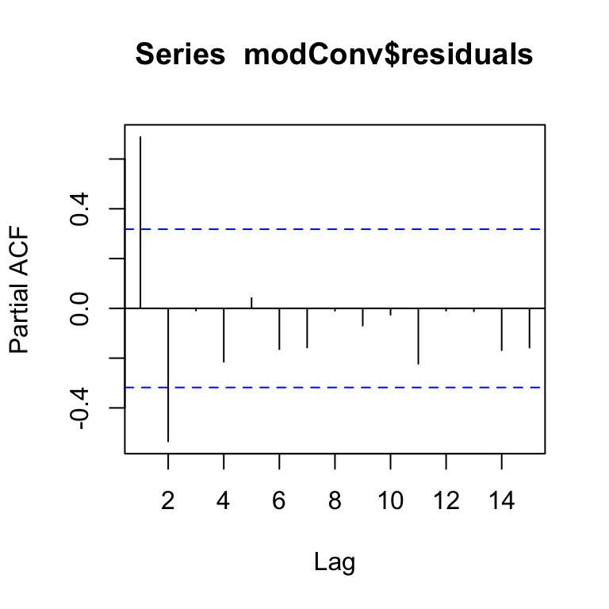

```r
pacf(modConv$residuals)
```

but mind that the CI plotted here are very aproximative.

## Testing for independence induced by a specific variable

```r
library(lmtest)
dwtest(modConv, order.by = modConv$model$degrees)
```

```
##
##  Durbin-Watson test
##
## data:  modConv
## DW = 1.0979, p-value = 0.000293
## alternative hypothesis: true autocorrelation is greater than 0
```

## Testing for independence by eye

### It is difficult when the problem is not extreme

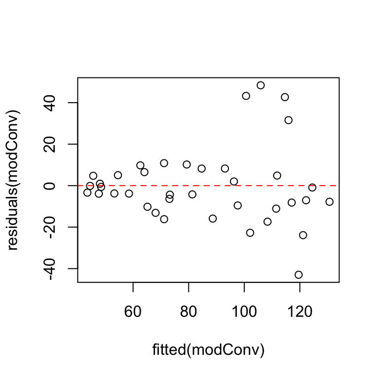

```r
plot(residuals(modConv) ~ fitted(modConv))
abline(h = 0, lty = 2, col = "red")
```

## Testing for independence by eye

### The origin of the problem is here the time!

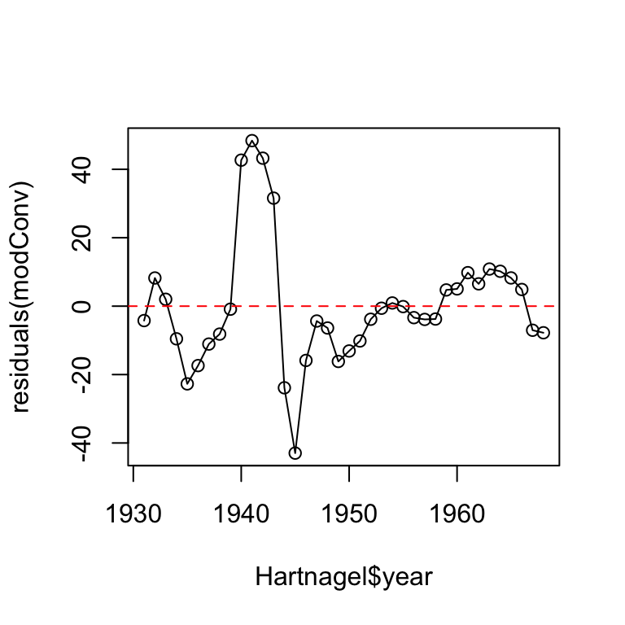

```r
plot(residuals(modConv) ~ Hartnagel$year, type = "o")
abline(h = 0, lty = 2, col = "red")
```

## Constant variance (homoscedasticity)

## Homos(c/k)edasticity in brief

### Assumption

The variance of the error (not residuals) is constant: \(\text{var}(\epsilon_j) = \sigma^2\) for all \(j\). With matrix notation: if \(\epsilon^\text{T}\) is the vector of all \(\epsilon_j\), then we assume \(\text{cov}(\epsilon, \epsilon) = \text{E}(\epsilon \epsilon^\text{T}) = \sigma^2I_n\), where \(I_n\) is the \(n \times n\) identity matrix.

### Causes and consequences of violation

Heteros(c/k)edasticity can emerge when there is a mean - variance relationship, when there is non independence between observations, when reaction norm changes acording to the treatement. It can create both false positives and false negative.

### Solution

- transformation (see linearity)
- post-hoc correction of the SE (not so great)

### Alternative

- Generalized Linear Models (GLM)
- mixed models modeling the variance

## Example of heteroscedasticity

```r
set.seed(1L)
Alien5 <- simulate_Aliens(N = 100)
Alien5$eggs <- rpois(100, lambda = 2 + 1 * Alien5$humans_eaten)
mod_alien5 <- lm(eggs ~ humans_eaten, data = Alien5)
summary(mod_alien5)$coef
```

```
##               Estimate Std. Error   t value     Pr(>|t|)
## (Intercept)  4.0151515 1.40732691  2.853034 5.283196e-03
## humans_eaten 0.9490069 0.02419424 39.224505 1.013308e-61
```

```r
bptest(mod_alien5)
```

```
##
##  studentized Breusch-Pagan test
##
## data:  mod_alien5
## BP = 9.7525, df = 1, p-value = 0.001791
```

The Breusch-Pagan test follows a Chi-square distribution (thus stat | H0 = df).

## Testing for heteroscedasticity by eye

Residuals must be standardized as raw residuals always have some (minor) heteroscedasticity.

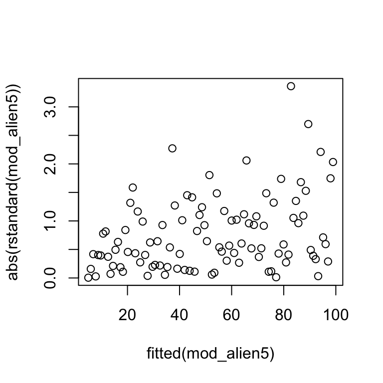

```r
plot(abs(rstandard(mod_alien5)) ~ fitted(mod_alien5))
```

## Post-hoc correction (not optimal)

```r
vcov(mod_alien5)
```

```
##              (Intercept) humans_eaten
## (Intercept)   1.98056903 -0.029560732
## humans_eaten -0.02956073  0.000585361
```

```r
hccm(mod_alien5)  ## correct the covariance matrix of parameter estimates
```

```
##              (Intercept)  humans_eaten
## (Intercept)   1.25607314 -0.0240113311
## humans_eaten -0.02401133  0.0006539282
```

```r
estimates <- coef(mod_alien5)
std.errors <- sqrt(diag(hccm(mod_alien5)))
t.values <- estimates/std.errors
p.values <- 2*pt(abs(t.values), df = mod_alien5$df.residual, lower.tail = FALSE)
cbind(estimates, std.errors, t.values, p.values)
```

```
##              estimates std.errors  t.values     p.values
## (Intercept)  4.0151515 1.12074669  3.582568 5.318817e-04
## humans_eaten 0.9490069 0.02557202 37.111144 1.643187e-59
```

## Post-hoc correction (not optimal)

Same using `Anova`:

```r
Anova(mod_alien5, white.adjust = TRUE)  ## vcov = hccm
```

```
## Coefficient covariances computed by hccm()
```

```
## Analysis of Deviance Table (Type II tests)
##
## Response: eggs
##              Df      F    Pr(>F)
## humans_eaten  1 1377.2 < 2.2e-16 ***
## Residuals    98
## ---
## Signif. codes:  0 '***' 0.001 '**' 0.01 '*' 0.05 '.' 0.1 ' ' 1
```

```r
37.111144^2  ## t^2 from previous slide
```

```
## [1] 1377.237
```

## Normality

## Normality in brief

### Assumption

The errors (not the residuals) should be normaly distributed.

### Causes and consequences of violation

The distribution of residuals can be skewed, this is often caused by the presence of outliers, and/or when the process generating the data is very different from normal (e.g. Poisson, Binomial…).

### Solution

- transformation (see linearity)
- taking outliers out (mindfully!)

### Alternative

- robust regressions
- GLM

## Testing normality

### There are many tests for normality out there…

Example: the Lilliefors (Kolmogorov-Smirnov) test for normality, Shapiro-Wilk Normality Test…

```r
library(nortest)
lillie.test(mod_poison$residuals)   ## stat = 0 when normal
```

```
##
##  Lilliefors (Kolmogorov-Smirnov) normality test
##
## data:  mod_poison$residuals
## D = 0.114, p-value = 0.1228
```

```r
shapiro.test(mod_poison$residuals)  ## stat = 1 when normal
```

```
##
##  Shapiro-Wilk normality test
##
## data:  mod_poison$residuals
## W = 0.92242, p-value = 0.003622
```

## Testing normality by eye

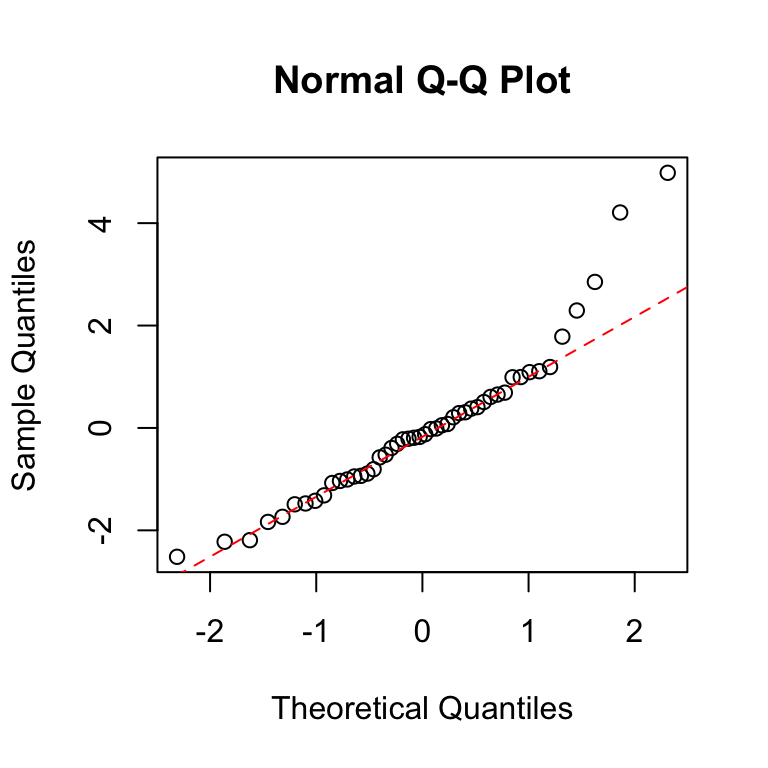

```r
qqnorm(mod_poison$residuals)
qqline(mod_poison$residuals, col = 2, lty = 2)
```

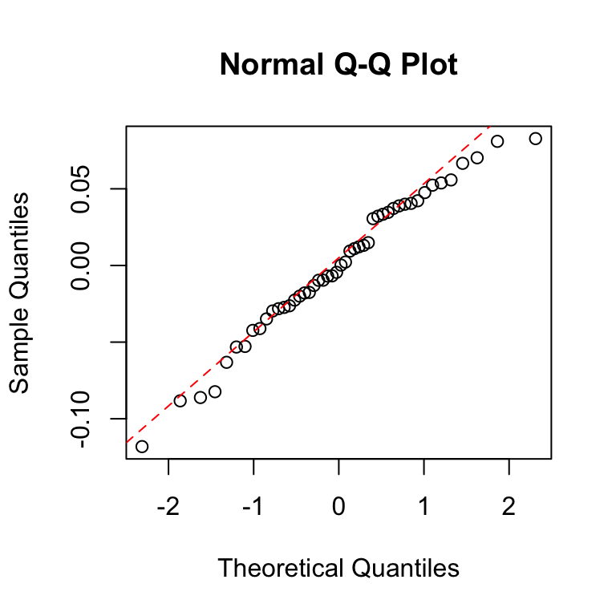

```r
qqnorm(mod_poison2$residuals)
qqline(mod_poison2$residuals, col = 2, lty = 2)
```

## Testing all assumptions on the errors at once

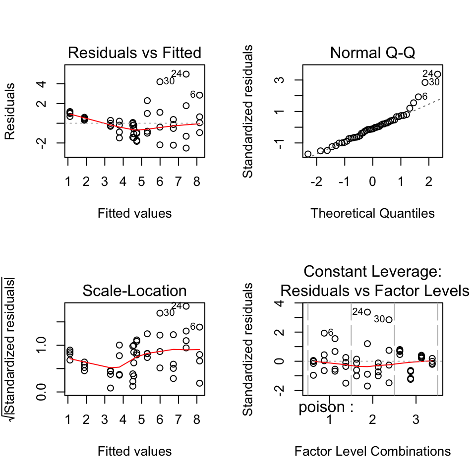

```r
par(mfrow = c(2, 2))
plot(mod_poison)
```

## Outliers

## Outliers in brief

### What are they?

They are observation that seem not to belong to the others.

### Why do they matter?

A few very deviant points can strongly influence all your estimations.

### What should you do with them?

It depends… but never trash them blindly.

If you have very good reasons to take them out, do mention it in the paper!

## Example

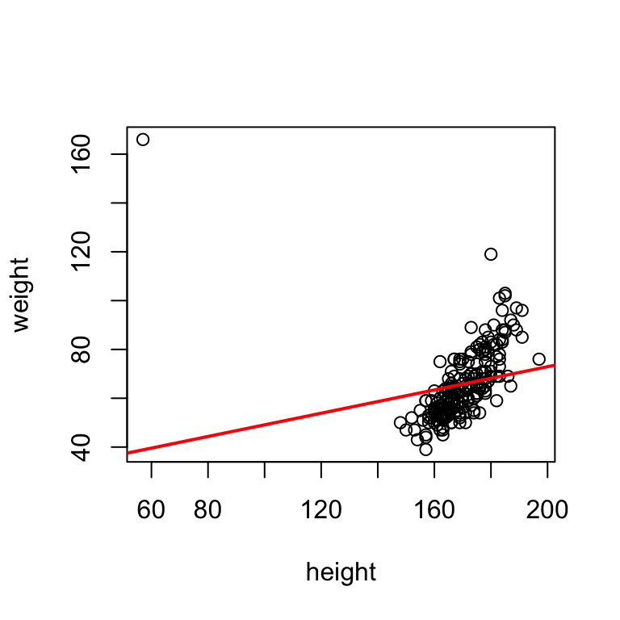

```r
data(Davis)
mod_davis <- lm(weight ~ height, data = Davis)
plot(weight ~ height, data = Davis)
abline(mod_davis, col = "red", lwd = 2)
```

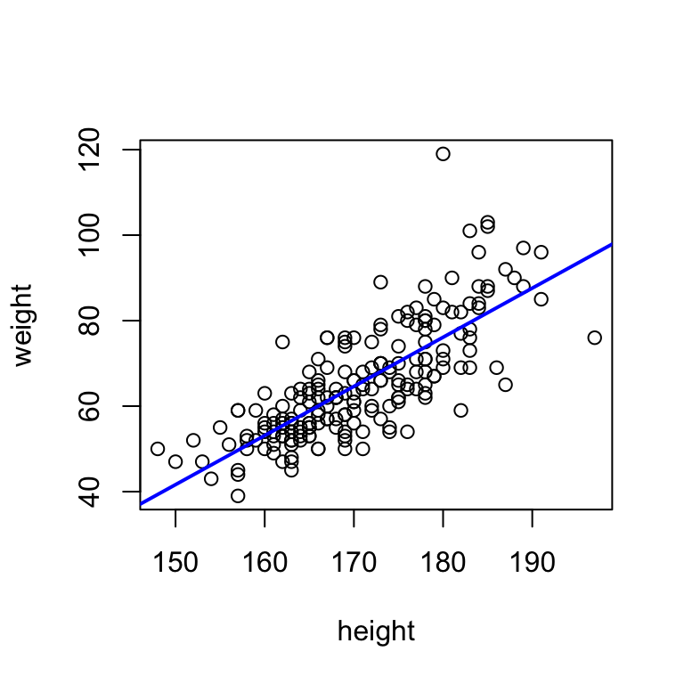

```r
# with(Davis, identify(height, weight,
#   row.names(Davis))) # click and escape
mod_davis2 <- update(mod_davis, data = Davis[-12, ])
plot(weight ~ height, data = Davis[-12, ])
abline(mod_davis2, col = "blue", lwd = 2)
```

## Many ways to be an outlier

```r
influence.measures(mod_davis)  ## In the next slides we will see all that in details!
```

```
## Influence measures of
##   lm(formula = weight ~ height, data = Davis) :
##
##        dfb.1_  dfb.hght     dffit cov.r   cook.d     hat inf
## 1   -3.71e-02  4.00e-02  0.056630 1.017 1.61e-03 0.01000
## 2   -2.22e-02  2.04e-02 -0.033849 1.017 5.75e-04 0.00784
## 3   -4.19e-02  3.84e-02 -0.063867 1.013 2.04e-03 0.00784
## 4   -1.31e-03  1.49e-03  0.002964 1.017 4.42e-06 0.00670
## 5   -2.05e-02  1.93e-02 -0.026203 1.021 3.45e-04 0.01091
## 6    3.51e-03 -8.14e-05  0.048743 1.010 1.19e-03 0.00500
## 7    1.68e-02 -1.32e-02  0.053818 1.010 1.45e-03 0.00532
## 8    3.70e-03 -3.92e-03 -0.004894 1.024 1.20e-05 0.01390
## 9   -9.37e-03  1.05e-02  0.018948 1.017 1.80e-04 0.00722
## 10   5.59e-05 -4.03e-04 -0.004948 1.015 1.23e-05 0.00503
## 11  -4.96e-03  5.98e-03  0.015581 1.016 1.22e-04 0.00586
```

[output cut: 189 more lines]

## Leverage vs Influence

A regression outlier is an observation that has an unusual value of the dependent variable Y, conditional on X.

Regression outliers may not look at outliers on any Y or X variables.

### Leverage

The leverage quantifies how unusual on observation is in terms of X values.

A high leverage is not necessarily a bad thing.

### Influence

An observation is influential if it strongly influences the predicted values.

A high influence is not necessarily a bad thing.

We do not want high influence caused by high leverage!

### Conclusion: we need to look at both!

## Measuring the leverage

This is done by extracting the diagonal element of the hat matrix: the hat values.

Recall: \(\widehat{Y} = HY\)

- range: [1/n; 1]
- mean : k/n

```r
head(sort(hatvalues(mod_davis), decreasing = TRUE))
```

```
##         12         19        134        140        169        153
## 0.45016470 0.03036845 0.02189837 0.02033985 0.02033985 0.01896813
```

```r
X <- model.matrix(mod_davis)
head(sort(diag(X %*% solve(crossprod(X)) %*% t(X)), decreasing = TRUE))
```

```
##         12         19        134        140        169        153
## 0.45016470 0.03036845 0.02189837 0.02033985 0.02033985 0.01896813
```

For some computations and plots the leverage are rescaled as \(\frac{h_{i,i}}{1-h_{i,i}}\), but it does not change the reasoning.

## Measuring the leverage

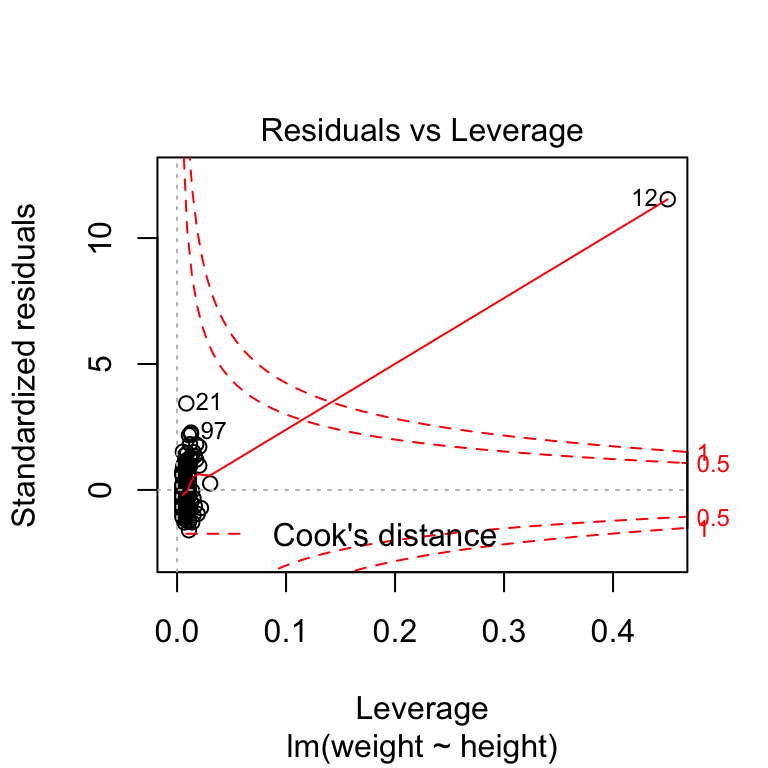

```r
plot(mod_davis, which = 5)
```

## Measuring the influence on predictions

```r
head(sort(dffits(mod_davis), decreasing = TRUE))
```

```
##         12         21         97         54        169         65
## 18.2026150  0.3265686  0.2623975  0.2543943  0.2481074  0.2435272
```

```r
head(sort(cooks.distance(mod_davis), decreasing = TRUE))
```

```
##          12          21          97          54         169          65
## 54.51622205  0.05040059  0.03369421  0.03172011  0.03047620  0.02930947
```

Both the DFFITS measure and the Cook distance (aka Cook's D) are two relative measures of the extent to which the predicted y-values changes if a given observation is dropped. DFFITS measures it scaled by the standard deviation of the fit at the point, Cook's D in the value of a F statistics comparing simultaneously the changes in all estimates when the observation is dropped or not.

A high value is obtained when the observation is associated to high leverage, high residual or both.

## Measuring the influence on predictions

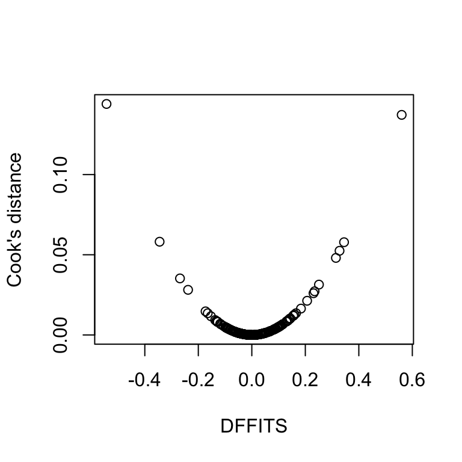

```r
plot(dffits(mod_davis2), cooks.distance(mod_davis2), xlab = "DFFITS", ylab = "Cook's distance")
```

## Measuring the influence on predictions

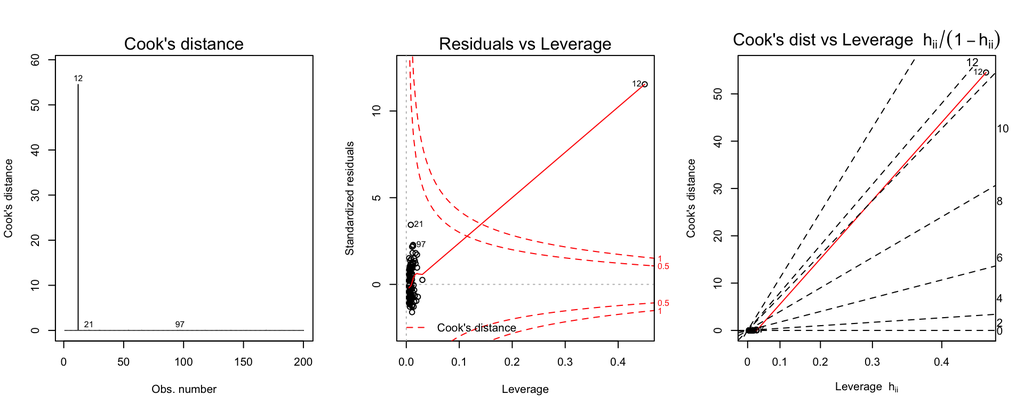

```r
par(mfrow = c(1, 3))
plot(mod_davis, which = 4:6)
```

## Measuring the influence on predictions with another example

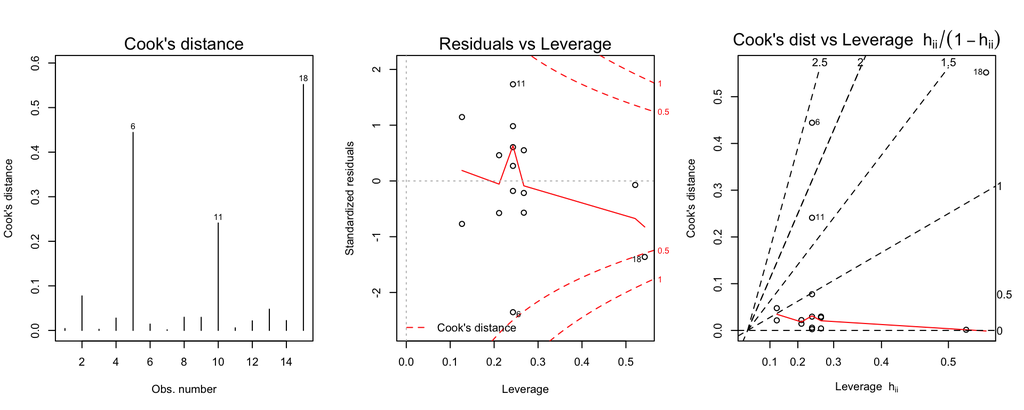

```r
mod_UK <- lm(height ~ sex * milk, data = UK[1:20, ])
par(mfrow = c(1, 3))
plot(mod_UK, which = 4:6)
```

## Measuring the influence on predictions with another example bis

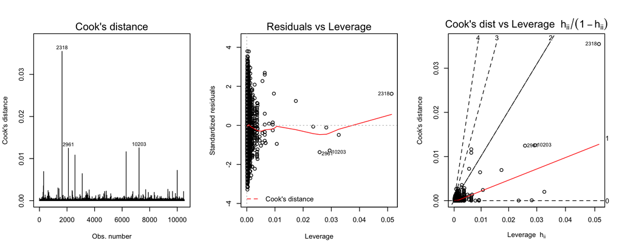

```r
mod_UK2 <- lm(height ~ sex * milk, data = UK)
par(mfrow = c(1, 3))
plot(mod_UK2, which = 4:6)
```

## Measuring the influence on each parameter estimates

```r
head(dfbeta(mod_davis), n = 3)
```

```
##   (Intercept)      height
## 1  -0.5561349 0.003518856
## 2  -0.3328040 0.001789983
## 3  -0.6273427 0.003374158
```

```r
coef(mod_davis) - coef(update(mod_davis, data = Davis[-1, ]))
```

```
##  (Intercept)       height
## -0.556134884  0.003518856
```

```r
head(dfbetas(mod_davis), n = 3) ## same in SE units
```

```
##   (Intercept)     height
## 1 -0.03713444 0.04004730
## 2 -0.02221240 0.02036250
## 3 -0.04191028 0.03841989
```

## Measuring the influence on the estimation of the covariance matrix

```r
head(sort(covratio(mod_davis), decreasing = TRUE))
```

```
##       19      134       40        8      107      140
## 1.041119 1.027424 1.024492 1.024399 1.022624 1.021466
```

```r
det(vcov(update(mod_davis, data = Davis[-19, ]))) / det(vcov(mod_davis))
```

```
## [1] 1.041119
```

## Exploring in depth outliers: all at once

Note: don't trust much rule of thumbs to identify outliers "automatically". If you still want to know some of them, you can look at the beginning of the code of the function `influence.measures()`.

```r
influence.measures(mod_davis)  ## stars are just there to attract your attention, there is no proper tests!
```

```
## Influence measures of
##   lm(formula = weight ~ height, data = Davis) :
##
##        dfb.1_  dfb.hght     dffit cov.r   cook.d     hat inf
## 1   -3.71e-02  4.00e-02  0.056630 1.017 1.61e-03 0.01000
## 2   -2.22e-02  2.04e-02 -0.033849 1.017 5.75e-04 0.00784
## 3   -4.19e-02  3.84e-02 -0.063867 1.013 2.04e-03 0.00784
## 4   -1.31e-03  1.49e-03  0.002964 1.017 4.42e-06 0.00670
## 5   -2.05e-02  1.93e-02 -0.026203 1.021 3.45e-04 0.01091
## 6    3.51e-03 -8.14e-05  0.048743 1.010 1.19e-03 0.00500
## 7    1.68e-02 -1.32e-02  0.053818 1.010 1.45e-03 0.00532
## 8    3.70e-03 -3.92e-03 -0.004894 1.024 1.20e-05 0.01390
## 9   -9.37e-03  1.05e-02  0.018948 1.017 1.80e-04 0.00722
## 10   5.59e-05 -4.03e-04 -0.004948 1.015 1.23e-05 0.00503
## 11  -4.96e-03  5.98e-03  0.015581 1.016 1.22e-04 0.00586
```

[output cut: 189 more lines]

## What you need to remember

- the six main assumptions behind LM
- how to check if these assumptions are met (by means of tests and using your eyes)
- how to do the Box-Cox transformation
- that you can manipulate the design matrix to solve problems
- how to study carefully outliers
- that you will have to learn GLM and (G)LMM to solve some usual problems

## Table of contents

## The Linear Model: LM

- 2.0 Introduction
- 2.1 Point estimates
- 2.2 Uncertainty in point estimates
- 2.3 Tests
- 2.4 Assumptions and Outliers
- 2.5 Let's practice more